# Popular Names

Yishan Han

2/15/2016

*Source file* ⇒ Lab_4.Rmd

## Step 1

BabyNames is the raw data from the US Social Security Administration.

- A case is a year-name-sex, for example, Jane F 1992 is a case.

Variables:

- name
- sex
- count
- year

## Step 3

| name | popularity | year |
| --- | --- | --- |
| Cora | 1045 | 1880 |
| Cora | … | … |
| Gertrude | 787 | 1880 |
| Gertrude | … | … |
| Myrtle | 615 | 1880 |
| Myrtle | … | … |

- The variable `sex` does not appear at all
- The variable `popularity` is similar to the variable `count` in the raw data table, but is transformed by giving the total portion of selected baby names over the total number of babies born in the given year. This gives us a more accurate representation of how popular the names were in a given year.

## Step 4

- The cases in the glyph-ready table have been filtered out by the names for all years.
- Yes, the cases have been grouped by `name` and `year`. We also summarised the `count` to find the sum of the `count` for when the `name` and `year` are the same. In this way, we can aggregate the count for the names that appear twice in one year due to different sexes.
- Yes, the variable `popularity` has been introduced. The relationship between `popularity` and `count` is that `popularity` is the proportion of the count of `names` over the total number of babies born in each chosen year.

## Step 5

1. Create a table for the baby names and filter by names of interest
2. Select the columns `name`, `count` and `year`
3. Group by the columns of `name` and `year`
4. Add up the total of `count` for the names that are repeated in every year
5. Create another table based on the first `BabyNames` data table by grouping by `year`.
6. Summarise the total `count` of all names in a certain year. This allows us to find the total number of babies born in a certain year.
7. Join the two tables by `year`
8. Create another column and call it `Popularity`, which is the proportion of number of `name` in a `year` over the total number of babies born.
9. Join the two tables together and find the popularity of the names by dividing the count by the total number of babies born in the year

## Step 7

```r
BabyNames3 <- BabyNames %>%
  filter(name %in% c("Cora", "Gertrude", "Myrtle")) %>%
  select(name, count, year) %>%
  group_by(name,year) %>%
  summarise(count = sum(count))
BabyNames3
```

```
## Source: local data frame [387 x 3]
## Groups: name [?]
##
##     name  year count
##    (chr) (int) (int)
## 1   Cora  1880  1051
## 2   Cora  1881   976
## 3   Cora  1882  1076
## 4   Cora  1883  1081
## 5   Cora  1884  1253
## 6   Cora  1885  1258
## 7   Cora  1886  1237
## 8   Cora  1887  1257
## 9   Cora  1888  1442
## 10  Cora  1889  1372
## ..   ...   ...   ...
```

```r
Total <- BabyNames %>%
  group_by(year) %>%
  summarise(totalinyear = sum(count))
Total
```

```
## Source: local data frame [134 x 2]
##
##     year totalinyear
##    (int)       (int)
## 1   1880      201484
## 2   1881      192700
## 3   1882      221537
## 4   1883      216952
## 5   1884      243468
## 6   1885      240856
## 7   1886      255320
## 8   1887      247396
## 9   1888      299481
## 10  1889      288952
## ..   ...         ...
```

```r
Join <- BabyNames3 %>%
  full_join(Total) %>%
  mutate(Popularity = count/totalinyear)%>%
  group_by(name,year)
Join
```

```
## Source: local data frame [387 x 5]
## Groups: name, year [387]
##
##     name  year count totalinyear  Popularity
##    (chr) (int) (int)       (int)       (dbl)
## 1   Cora  1880  1051      201484 0.005216295
## 2   Cora  1881   976      192700 0.005064868
## 3   Cora  1882  1076      221537 0.004856976
## 4   Cora  1883  1081      216952 0.004982669
## 5   Cora  1884  1253      243468 0.005146467
## 6   Cora  1885  1258      240856 0.005223038
## 7   Cora  1886  1237      255320 0.004844901
## 8   Cora  1887  1257      247396 0.005080923
## 9   Cora  1888  1442      299481 0.004814997
## 10  Cora  1889  1372      288952 0.004748193
## ..   ...   ...   ...         ...         ...
```

## Graph of Cora, Gertrude and Myrtle

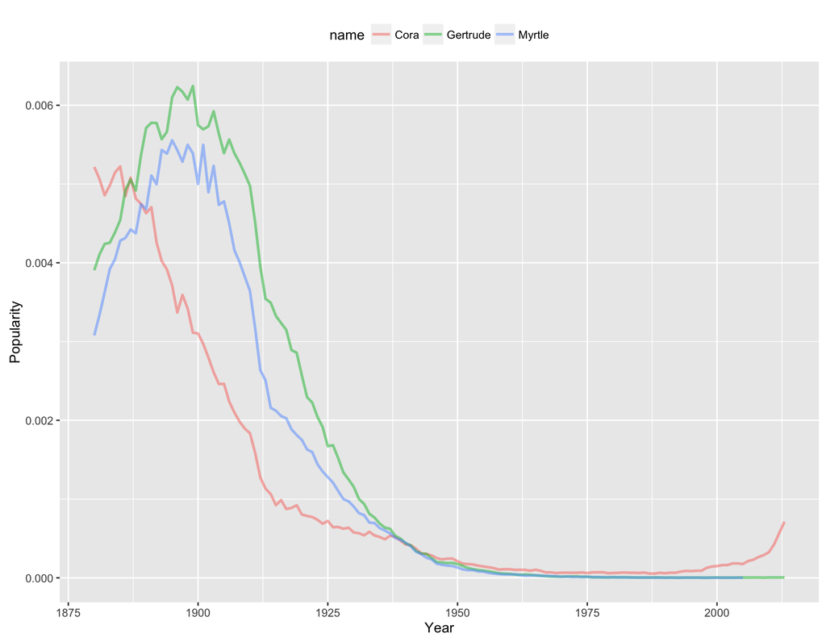

```r
Join %>%
  ggplot(aes(x= year, y = Popularity, group = name)) + geom_line(size = 1, alpha = 0.5, aes(color = name)) + ylab("Popularity") + xlab("Year") + theme(legend.position = 'top')
```